# Métodos Markov Chain Monte Carlo

Víctor Morales Oñate [Sitio personal](https://sites.google.com/site/moralesonatevictor/) [ResearchGate](https://www.researchgate.net/profile/Victor_Morales-Onate) [GitHub](https://github.com/vmoprojs) [LinkedIn](https://www.linkedin.com/in/vmoralesonate/)

09 de mayo de 2019

**Paquetes de esta sección**

```r
if(!require(ISLR)){install.packages("LearnBayes")}
```

- Vamos a ilustrar el uso de algoritmos MCMC para resumir distribuciones posteriores.
- También veremos dos variantes de MCMC: Metropolis-Hastings y Gibbs *sampling*, donde la cadena de Markov se configura a través de la distribución condicional de la posterior.

# Cadena de markov discreta

Supongamos que una persona se mueve en la línea recta de valores 1,2,3,4,5 y 6. Si la persona está en un punto interior (2,3,4,5), en el siguiente segundo puede quedarse en ese punto o moverse a *algún* punto vecino. Si decide moverse, hay igual probabilidad de que se mueva a la izquierda o a la derecha. Si la persona está en uno de los extremos (1 o 6), al siguiente segundo puede, con igual probabilidad, quedarse o moverse *al* punto vecino.

Lo anterior es un ejemplo de una cadena de Markov discreta. **Una cadena de Markov describe el movimiento probabilístico entre un número de estados**.

En el ejemplo hay 6 posibles estados que describen la posición del caminante. Dado que están en una posición, se mueve a otro punto con una determinada probabilidad. **La probabilidad de que se mueva a otra posición depende solamente de su posición actual y no de las anteriores.**

Esta matriz de transición tiene algunas propiedades interesantes, es:

- Irreducible: es posible ir desde cualquier estado hasta cualquier otro en uno o más pasos,
- Periódica: Si una persona puede únicamente regresar a este estado en intervalos regulares dado que una persona está en un estado particular. Nuestra matriz es *aperiódica*.

Podemos representar la posición actual como un vector de la forma:

$$p = (p_1,p_2,p_3,p_4,p_5,p_6),$$

donde $p_i$ representa la probabilidad de que una persona está actualmente en el estado $i$.

Si $p_i^j$ representa la posición del viajero en el paso $j$, entonces la posición del viajero en el paso $j+1$ se da por el producto matricial

$$p^{j+1} = p^jP.$$

Supongamos que podemos encontrar un vector $w$ tal que $wP=w$. Entonces se dice que $w$ es la **distribución estacionaria**.

Si una cadena de markov es estacionaria y aperiódica, entonces tiene una única distribución estacionaria.

**En `R`**

Hacemos el siguiente experimento. Iniciamos nuestra caminata aleatoria en un estado particular, digamos 3, y luego simulamos muchos pasos de la cadena de Markov usando la matriz de transición $P$.

La frecuencia relativa de nuestro viajero en las seis posiciones después de muchos pasos eventualmente se acerca a la distribución $w$.

```r
P <- matrix(c(.5,.5,0,0,0,0,.25,.5,.25,0,0,0,0,.25,.5,.25,0,0,
 0,0,.25,.5,.25,0,0,0,0,.25,.5,.25,0,0,0,0,.5,.5),
 nrow=6,ncol=6,byrow=TRUE)
P
```

```
##      [,1] [,2] [,3] [,4] [,5] [,6]
## [1,] 0.50 0.50 0.00 0.00 0.00 0.00
## [2,] 0.25 0.50 0.25 0.00 0.00 0.00
## [3,] 0.00 0.25 0.50 0.25 0.00 0.00
## [4,] 0.00 0.00 0.25 0.50 0.25 0.00
## [5,] 0.00 0.00 0.00 0.25 0.50 0.25
## [6,] 0.00 0.00 0.00 0.00 0.50 0.50
```

Indicamos que la ubicación de inicio para nuestro viajero es el estado 3 y realizamos un bucle para simular $50000$ realizaciones de la cadena de Markov

```r
s <- array(0,c(50000,1))
```

Simulamos:

```r
set.seed(1)
s[1]=3
for (j in 2:50000)
  s[j]=sample(1:6,size=1,prob=P[s[j-1],])
```

Resumimos las frecuencias de visitas en diferentes puntos de corte y vemos la precuencia relativa:

```r
m=c(500,2000,8000,50000)
for (i in 1:4)
  print(table(s[1:m[i]])/m[i])
```

```
##
##     1     2     3     4     5     6
## 0.094 0.170 0.188 0.198 0.262 0.088
##
##      1      2      3      4      5      6
## 0.0965 0.1900 0.2065 0.2110 0.2055 0.0905
##
##       1       2       3       4       5       6
## 0.09050 0.19275 0.21100 0.21350 0.20000 0.09225
##
##       1       2       3       4       5       6
## 0.10212 0.20108 0.19846 0.20088 0.19884 0.09862
```

Parece que las frecuencias relativas están convergiendo a la distribución estacionaria $w = (0.1,0.2,0.2,0.2,0.2,0.1)$. Podemos confirmar que efectivamente converge con $wP=w$:

```r
w <- matrix(c(.1,.2,.2,.2,.2,.1),nrow=1,ncol=6)
w%*%P
```

```
##      [,1] [,2] [,3] [,4] [,5] [,6]
## [1,]  0.1  0.2  0.2  0.2  0.2  0.1
```

# El algoritmo Metropolis-Hastings.

- Una forma popular de simular a partir de una distribución posterior general es mediante el uso de los métodos de la cadena de Markov Monte Carlo (MCMC).
- Esto es esencialmente una generalización de valores continuos de la configuración de la cadena de Markov discreta descrita en la sección anterior.
- La estrategia de muestreo MCMC establece una cadena de Markov aperiódica e irreducible para la cual la distribución estacionaria es igual a la distribución posterior de interés.
- Una forma general de construir una cadena de Markov es mediante el uso de un algoritmo Metropolis-Hastings. En esta sección, nos centramos en dos variantes particulares de los algoritmos de Metropolis-Hastings, **la cadena de independencia** y la cadena de **caminata aleatoria**, que son aplicables a una amplia variedad de problemas de inferencia bayesianos.

Supongamos que queremos muestrear desde una densidad posterior $g(\theta|y)$ (que también notaremos como $g(\theta)$.

El almoritmo Metropolis-Hastings empieza con un valor inicial $\theta^0$ y especifica una regla para simular el valor $t$th en la secuencia $\theta^t$ dado el valor $(t-1)$ en la secuencia $\theta^{t-1}$.

Esta regla se llama **densidad propuesta** la cual simula un valor candidato $\theta^*$, y el cálculo de una **probabilidad de aceptación** $P$. La cual indica la probabilidad de que un valor candidato sea aceptado como siguiente valor en la secuencia.

Específicamente, este algoritmo se describe:

1. Simula el valor candidato $\theta^*$ desde una densidad propuesta $p(\theta^*|\theta^{t-1})$.
2. Calcula el ratio

$$R = \frac{g(\theta^*)p(\theta^{t-1}|\theta^*)}{g(\theta^{t-1})p(\theta^{*}|\theta^{t-1})}$$
3. Calcula la probabilidad de aceptación $P = min\{R,1\}$ 4. Muestrea un valor $\theta^t$ tal que $\theta^t=\theta^*$ con probabilidad $P$; en otro caso $\theta^t = \theta^{t-1}$.

La secuencia simulada $\theta^1,\theta^2,\ldots$ va a converger a una variable aleatoria que se distribuye como la distribución posterior $g(\theta)$.

Se configuran variantes del Metropolitan-Hastings dependiento de la función de densidad propuesta. Si la función de densidad propuesta es independiente del valor actual en la secuencia,

$$p (\theta^*|\theta^{t-1}) = p (\theta)$$
entonces el algoritmo resultante se llama *cadena indenpendiente*.

Otra opción es permitiendo que la densidad tenga la forma

$$p (\theta^*|\theta^{t-1}) = h (\theta^*-\theta^{t-1}),$$

donde $h$ es una densidad simétrica respecto al origen. En este tipo de cadena de *caminata aleatoria*, el ratio $R$ tiene la forma simple:

$$R = \frac{g(\theta^*)}{g(\theta^{t-1})}$$

Las funciones `rwmetrop` y `indepmetrop` del paquete `LearnBayes` las implementan.

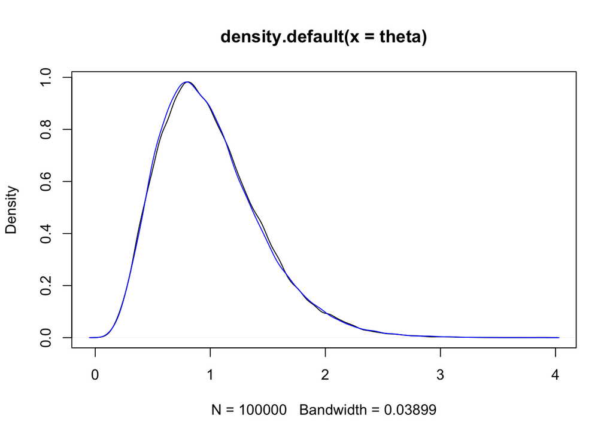

```r
#Definimos los parametros:
nreps <- 100000
prop_sd <- 1
dens <- function(x){dgamma(x,shape = 5, rate = 5)}
start <- 2

theta <- numeric(nreps)
theta[1] <- start

for (i in 2:nreps)
{
  # i = 2
  theta_star <- rnorm(1, mean = theta[i - 1], sd = prop_sd)
  alpha <- dens(theta_star)/dens(theta[i - 1])


  if(runif(1) < alpha){
    theta[i] <- theta_star
  }else
  {
      theta[i] <- theta[i - 1]
  }
}

plot(density(theta))
lines(density(rgamma(nreps, 5,5)), col = "blue")
```

# Muestreo de Gibbs

Veamos la simulación a partir de una normal bivariada con una media cero y una varianza 1 para las marginales, pero una correlación de *rho* entre los dos componentes.

Por supuesto, no necesitamos una muestra de Gibbs para simular esto, simplemente podríamos simular desde el marginal para $X$, y luego desde el condicional para $Y|X$. En R, podríamos hacer esto de la siguiente manera:

```r
rbvn<-function (n, rho)
{
        x <- rnorm(n, 0, 1)
        y <- rnorm(n, rho * x, sqrt(1 - rho^2))
        cbind(x, y)
}
```

Esto crea un vector de valores $X$, luego los usa para construir vectores de valores $Y$ condicionales en esos valores $X$. Estos se unen entonces en una matriz $n\times 2$. Podemos probarlo con:

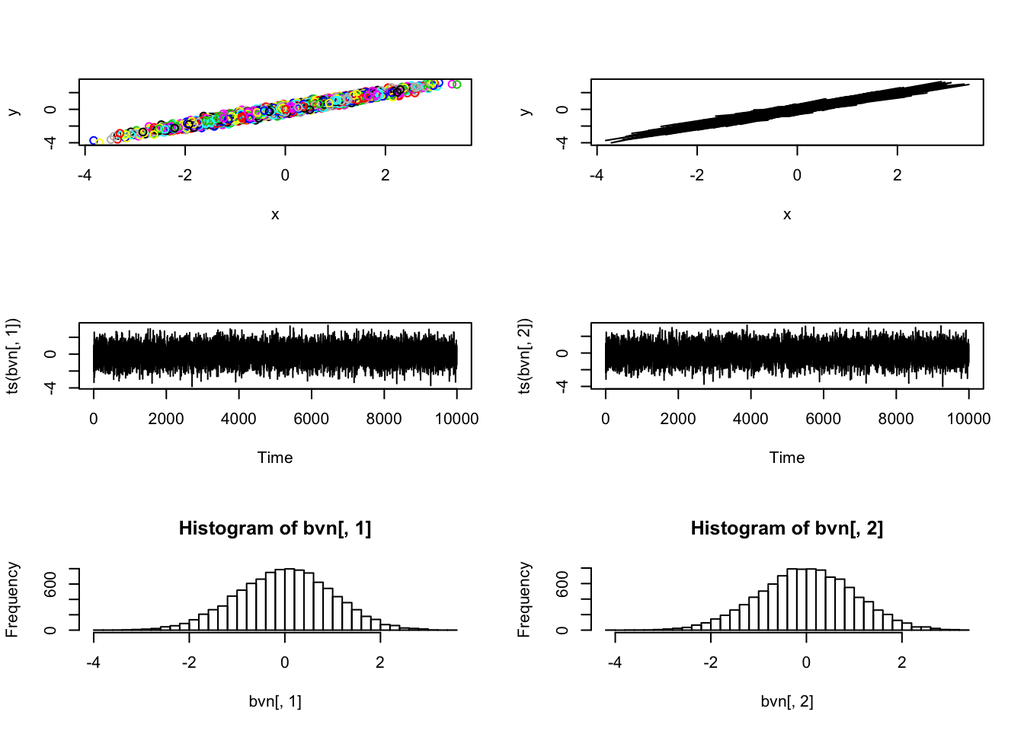

```r
bvn<-rbvn(10000,0.98)
par(mfrow=c(3,2))
plot(bvn,col=1:10000)
plot(bvn,type="l")
plot(ts(bvn[,1]))
plot(ts(bvn[,2]))
hist(bvn[,1],40)
hist(bvn[,2],40)
```

```r
par(mfrow=c(1,1))
```

Esto proporciona un par de gráficos de dispersión de los puntos, gráficos de series de tiempo de las marginales para confirmar que estamos muestreando de forma independiente, y luego histogramas de las dos marginales.

Sin embargo, también podemos hacerlo usando muestreo de Gibbs. Podemos construir una muestra de Gibbs para este problema muestreando sucesivamente las distribuciones condicionales.

```r
gibbs<-function (n, rho)
{
        mat <- matrix(ncol = 2, nrow = n)
        x <- 0
        y <- 0
        mat[1, ] <- c(x, y)
        for (i in 2:n) {
                x <- rnorm(1, rho * y, sqrt(1 - rho^2))
                y <- rnorm(1, rho * x, sqrt(1 - rho^2))
                mat[i, ] <- c(x, y)
        }
        mat
}
```

Se crea una matriz para los resultados, luego la cadena se inicializa en $(0,0)$. El bucle principal luego toma muestras sucesivas de los condicionales completos, almacenando los resultados en la matriz. Podemos probar esto de la siguiente manera.

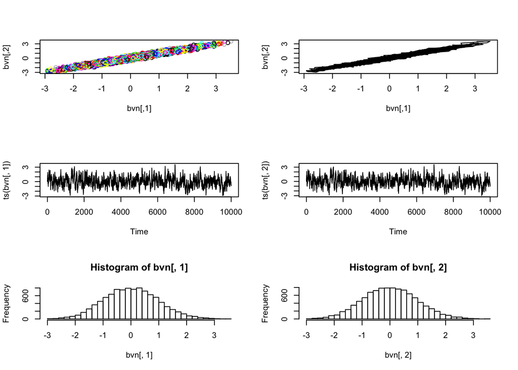

```r
bvn<-gibbs(10000,0.98)
par(mfrow=c(3,2))
plot(bvn,col=1:10000)
plot(bvn,type="l")
plot(ts(bvn[,1]))
plot(ts(bvn[,2]))
hist(bvn[,1],40)
hist(bvn[,2],40)
```

```r
par(mfrow=c(1,1))
```

Con un poco de suerte, esto dará resultados que se verán muy similares a los obtenidos anteriormente, además de las gráficas de series de tiempo de los marginales, que muestran una autocorrelación distinta entre los valores sucesivos.

## En Bayesiano…

Supongamos que $Y \sim N(mean = \mu, Var = \frac{1}{\tau})$.

Basado en esta muestra, obtener las distrubuciones posteriores de $\mu$ y $\tau$ usando el muestreo de Gibbs.

**Notación**

$\mu$ = media poblacional $\tau$ = precision (1/varianza) $n$ = tamaño muestral $\bar{y}$ = media muestral $s^2$ = varianza muestral

**Algoritmo**

En la iteración $i$ ($i=1,\ldots,,N$):

- muestrea $\mu^{(i)}$ de $f(\mu|\tau^{(i-1)},datos)$
- muestrea $\tau^{(i)}$ de $f(\tau|\mu^{(i)},datos)$

La teoría asegura que después de un gran número de iteraciones, $T$, el conjunto $\{(\mu^{(i)},\tau^{(i)}): i = T+1,\ldots,N\}$ puede ser visto como una muestra aleatoria de la distribución conjunta posterior.

**Distribuciones apriori**

$$f(\mu, \tau) = f(\mu) \times f(\tau)$$

con $f(\mu) \propto 1$ y $f(\tau) \propto \tau^{-1}$.

Condicional posterior para la media, dada la precisión

$$(\mu \,|\, \tau, \text{data}) \sim \text{N}\Big(\bar{y}, \frac{1}{n\tau}\Big)$$

Condicional posterior para la precisión, dada la media

$$(\tau \,|\, \mu, \text{data}) \sim \text{Gam}\Big(\frac{n}{2}, \frac{2}{(n-1)s^2 + n(\mu - \bar{y})^2} \Big)$$

**En R**

```r
# resumen estadistico de la meustra
n    <- 30
ybar <- 15
s2   <- 3

# muestra de la posterior conjunta (mu, tau | data)
mu     <- rep(NA, 11000)
tau    <- rep(NA, 11000)
T      <- 1000    # datos quemados
tau[1] <- 1  # valor de inicio
for(i in 2:11000) {
    mu[i]  <- rnorm(n = 1, mean = ybar, sd = sqrt(1 / (n * tau[i - 1])))
    tau[i] <- rgamma(n = 1, shape = n / 2, scale = 2 / ((n - 1) * s2 + n * (mu[i] - ybar)^2))
}
mu  <- mu[-(1:T)]   # remuevo los quemados
tau <- tau[-(1:T)] #  remuevo los quemados
```

# Referencias

Albert, J. (2009) Bayesian Computation with R. Springer. Casella, G. & George, E. I. (1992). *Explaining the Gibbs Sampler*. The American Statistician, 46, 167–174.]